# BaybAIyin OCR Model FINAL

```python
# !pip install opencv-python
```

```python
from IPython.display import HTML

HTML('''<script>
code_show=true;
function code_toggle() {
 if (code_show){
 $('div.input').hide();
 } else {
 $('div.input').show();
 }
 code_show = !code_show
}
$( document ).ready(code_toggle);
</script>
<form action="javascript:code_toggle()">
<input type="submit" value="Click here to toggle on/off the raw code.">
</form>''')
```

```python
import os
os.environ['TF_CPP_MIN_LOG_LEVEL'] = '2'
from pathlib import Path

from tqdm import tqdm
import numpy as np
import pandas as pd
import seaborn as sns
import matplotlib.pyplot as plt
%matplotlib inline

from PIL import Image
import pickle
import random
import gc
import cv2

import tensorflow as tf
tf.get_logger().setLevel('ERROR')
tf.autograph.set_verbosity(2)
from tensorflow.keras import models, layers, optimizers, applications
from tensorflow.keras.preprocessing import image
from tensorflow.keras.preprocessing.image import ImageDataGenerator
from tensorflow.keras.callbacks import ModelCheckpoint, EarlyStopping, ReduceLROnPlateau
from tensorflow.keras.optimizers import Adam

import keras_cv_attention_models
```

[output not shown]

[figure not shown]

## I. Executive Summary

Jose Rizal once said *‘While a people preserves its language, it preserves the marks of liberty’*. The study is concentrated on Baybayin, a commonly used writing system from the 16th through the 17th centuries. Baybayin comes from the Tagalog word *‘baybay’*, which means *‘to spell’*. Despite being a historic script, it has witnessed a resurgence in the modern Philippines, where it may be found on passports, insignia of government agencies, published publications, and mainstream culture. Congress has explored many bills to promote its use, including House Bill 1022 or the proposed "National Writing System Act", which proposes to proclaim Baybayin as the official National Writing System, emphasizing the necessity of promoting Baybayin's value and beauty as a tool for development through instilling pride in the Filipino identity.

**Methodology**

As Filipino data scientists, the proponents developed a real-time Optical Character Recognition (OCR) model that recognizes baybayin script in response to the call for cultural preservation. The model can recognize Baybayin script in real-time with **98.51%** accuracy using a mobile camera or webcam. A dataset of `38,000` photos of `19` different handwritten Baybayin characters was utilized to train the deep neural networks. The dataset was resized and data augmentation was peformed to prepare the data. A baseline `Convolutional Neural Network (CNN)`, `VGG-16`, `Resnet50`, `Efficientnet B0`, and state-of-the-art `CoAtNet` were all evaluated. The `VGG-16` model obtained the best results, with an accuracy of 98.51%. This is comparable to various previous studies that have an accuracy in the range of 84% - 96.5%, and the other letter classification models trained on the EMNIST dataset, with the highest accuracy of 95.88% for VGG-5(Spinal FC). It is notable that in this study, the older VGG-16 model was able to outperform the newer CoAtNet model.

**Recommendations for Further Study**

Recommendations for further study include improvements using object detection models so the predictions are independent of video framing, expanding the dataset to have words and paragraphs in Baybayin to allow conversion of entire passages, and also to account for different variations and its diacritics. Translation to other languages suchh as English and Spanish, or evaluating Baybayin alongside latin text can also be explored.

**Conclusion**

The findings of this study can be utilized to speed up the translation of Baybayin texts, assist linguists and historians in their research, and make Baybayin more accessible to the general public.

## II. Introduction

Early Filipinos used Baybayin as one of their pre-colonial writing systems. Baybayin is derived from the Tagalog root word *baybay*, which means *"to spell,"* and has been an integral part of Filipino culture and heritage. For many years, the script was wrongly referred to as "alibata," based on the layout of another alphabet system – Arabic. When the Spaniards arrived in the Philippines, they discovered that the majority of the natives, not only the elite, could read and write. The script was not only used for recording purposes, but it was also used to sign documents, write poetry, incantations, and letters. It was a common means of communication that was highly respected by the explorers who visited the islands.

Baybayin is an alphasyllabary. Each character is built around a consonant letter, with a vowel indication denoting the vowel sound it represents. It has `14` syllabic consonant characters and `3` vowel symbols. Each consonant symbol combines the consonant sound with the vowel sound "a." A *kudlit* or mark is added on top of the character to alter this to the "e-i" sound, and for the "o-u" sound, the mark is placed at the bottom.

The Spanish friars studied Baybayin and used it to teach Filipinos about the Catholic faith. To signify consonants that stand alone, the Spanish affixed a cross symbol at the bottom of Baybayin letters. As the colonizers brought their own method of writing, Baybayin was gradually superseded by the Latin alphabet, and its use dwindled and eventually died down. In recent years, however, Baybayin has seen a comeback in popularity, especially with Filipino millennials and young professionals. Baybayin calligraphy and fonts have captivated the digital generation, with tattoos, garments, posters, accessories, and mobile apps all featuring them. Government agencies, cultural organizations, and artists are all working to revive the archaic writing system. It is taught in classrooms, workshops, and public presentations.

The United Nations has chosen 2019 to be the International Year of Indigenous Languages. This is to raise awareness about how `40%` of the world's estimated 6,700 languages are on the verge of extinction, with the bulk of them being archaic scripts used by indigenous peoples. Baybayin is one of the several indigenous scripts in the Philippines that almost died out until it regained popularity.

The goal of the project is to utilize deep learning to answer the call for cultural preservation and provide assistance and encouragement in keeping the Philippine legacy alive. A dataset of `38,000` photos of `19` different handwritten baybayin characters, each with a few thousand samples, is used to develop an **Optical Character Recognition** model. Various models were considered such as a baseline `Convolutional Neural Network`, popular computer vision architectures like `VGG16`, `EfficientNet B0`, and `ResNet`, and lastly, `CoAtNet`, a state-of the-art architecture currently ranking highest on image classification. After training the data on 5 different models, the model that obtained the best test performance was `VGG16` with an accuracy of **98.51%**.

## III. Motivation of the Study

The government has promoted the use of Baybayin through Philippine House Bill 1022, otherwise known as the "National Writing System Act". The bill declares the need to remote, protect, preserve and conserve Baybayin and use it as a tool for cultural and economic development. According to the bill, it would require all manufacturers of locally produced processed food products to inscribe Baybayin scripts and translations in the labels, mandate local government units (LGUs) to include Baybayin in the street signage for street names, public facilities, and public buildings, among others. This study and the proposed Optical Character Recognition (OCR) tool can help prepare for the prevalence of Baybayin in the near future. Apps that can transliterate Baybayin in real time can use this model to help the public in reading the Baybayin scripts in documents or in public places.

Not only is it hoped that this study may be useful in making Baybayin more accessible to the general public, it may have value for researchers and historians as well. For instance, it may be used as an educational aid for those seeking to master the writing system, or analyze its usage and evolution. A specific use case might be the study of ancient baybayin scripts, the largest collection of which is housed in the Archives of the University of Santo Tomas. While these may already have been translated into latin text, scholars who wish to study or peruse the documents in their original form may use an OCR model to efficiently do so.

Most importantly, Baybayin calls us to remember our roots and be proud of our Filipino legacy. As aspiring Filipino data scientists, applying the deep learning models that we have learned is our way of answering the call for cultural preservation and enhance pride for the Filipino identity.

## IV. Problem Statement

To help preserve our Filipino heritage, we focused on answering the following questions.

**How can we use deep learning models to predict the Baybayin characters? How can we deploy this model to allow real-time classification of Baybayin characters?**

## V. Review of Related Literature

The team conducted a review of prior literature, which seemed especially fitting since this project is focused on paying due respect to past writings.

A study by a group from AIM MSDS 2020 created a machine learning model for image processing that could classify the 17 fundamental Baybayin letters. Crowdsourcing was used to acquire handwritten samples. Following that, the dataset was scanned and transformed into over 1,000 photographs of individual Baybayin letters. Their traditional ML model achieved an accuracy of 84% (Callos, Ongleo, Ortigas, Roberto, 2019).

In 2020, Feed-Forward Neural Network with Dropout Method (FFNNDM) and Convolutional Neural Network with Dropout Method (CNNDM) were employed by researchers from the Technological Institute of the Philippines (TIP) to recognize Baybayin symbols. The FFNNDM structure consists of three (3) convolutional layers, two (2) dense hidden layers, and one (1) output layer, with the CNN structure consisting of three (3) convolutional layers, two (2) dense hidden layers, and one (1) output layer. The results reveal that the FFNNDM is more accurate, with an accuracy of 92.4 percent, a loss of 0.25 percent, and an error rate of 7.55 percent, compared to 91.69 percent, a loss of 0.31 percent, and an error rate of 8.31 percent for the CNNDM (Daday, Fajardo, Medina, 2020).

And lastly, in 2021, analysts from the University of the Philippines Diliman, Institute of Mathematics, created a model to classify Baybayin characters as part of a four classification problem. Multiclass Support Vector Machines (SVM) classification was applied and it achieved a 96.5% accuracy (Pino, Mendoza, Sambayan, 2021).

## VI. Data Source

The dataset used was sourced from Github, at https://github.com/jmbantay/Baybayin-Handwritten-Character-Dataset. It is comprised of 38,398 images of 19 different handwritten baybayin characters, with the distribution as follows:

- 14 consonants, each with 2000 to 2500 samples
  - *ba, da/ra, ga, ha, ka, la, ma, na, nga, pa, sa, ta, wa,* and *ya*
- 3 vowels, each with about 1,300 samples
  - *a, e/i,* and *o/u*
- 2 special characters indicating punctuation or pauses, each with about 1,000 samples
  - "/" or *kuw* (short for “kuwit” or comma) and "//" or *tul* (short for “tuldok” or period)

**Accent Marks or Diacritics**

It may be noted that by default, consonants are followed by the vowel sound “a”. While there are accent marks (such as a dot, bar, or cross) or diacritics used in baybayin to modify the succeeding vowel sound into “e/i” or “o/u” or cancel them out altogether, these are not standardized and do not comprise part of the dataset.

## VII. Methodology

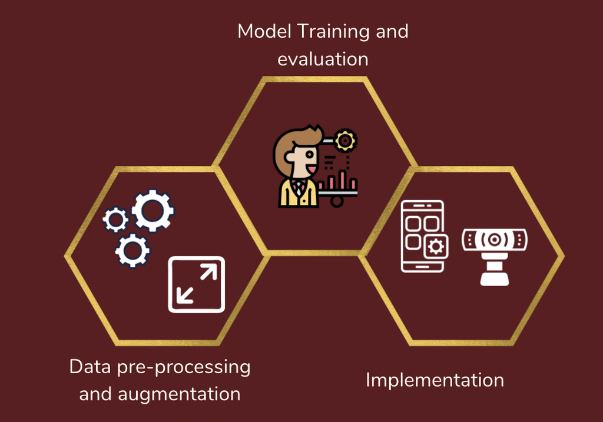

The approach in tackling the problem is outlined by the figure below.

**1. Data Pre-processing and augmentation**

The dataset was first inspected to ascertain the shape and the optical features of the samples. This was then resized to 64x64 so that the input to the model will have a uniform shape. The data was also augmented to allow for slight shifts in rotation, scale, brightness, and shear of the images to help the trained models become more robust.

**2. Model Training and Evaluation**

**3. Implementation**

Once the best model was found, a real-time character recognition model was made using OpenCV and deployed it using a mobile camera or a video camera on handwritten Baybayin script that researchers wrote.

## VIII. Preparing and Exploring the Dataset

Having downloaded the dataset from Github, the analysts proceeded to load the data and perform initial exploration. The distribution of samples are shown in both pie and bar plot form, below.

```python
# initialize the environment and set the random seeds for replicability
seed = 143
random.seed(seed)
np.random.seed(seed)
os.environ['PYTHONHASHSEED'] = str(seed)
tf.random.set_seed(seed)
```

```python
# set up some hyperparams and inspect the data, compute PCC
data_dir = '/mnt/processed/private/msds2022/cpt11/ML3/Baybayin-Handwritten-Character-Dataset/raw/'
save_dir = '/mnt/processed/private/msds2022/cpt11/ML3/Baybayin-Handwritten-Character-Dataset/savefiles/'
size = 64
epochs = 30
val_split = 0.25

batch_size = 32

data_path = Path(data_dir)
images = sorted(list(map(str, list(data_path.glob("*/*.jpg")))))
labels = set([img.split(os.path.sep)[-2] for img in images])
num_labels = len(labels)

label_dict = {i: j for i, j in zip(range(19), sorted(labels))}

steps_per_epoch = len(images) * (1 - val_split) / batch_size
validation_steps = len(images) * val_split / batch_size

print("Number of images found: ", len(images))
print("Number of labels found: ", num_labels)
print("Labels:", sorted(labels))

dist = pd.Series([img.split(os.path.sep)[-2] for img in images]).value_counts()
PCC = sum(pd.Series([img.split(os.path.sep)[-2] for img in images]).
       value_counts(normalize=True)**2)
```

```
Number of images found:  38398
Number of labels found:  19
Labels: ['a', 'ba', 'dara', 'ei', 'ga', 'ha', 'ka', 'kuw', 'la', 'ma', 'na', 'nga', 'ou', 'pa', 'sa', 'ta', 'tul', 'wa', 'ya']
```

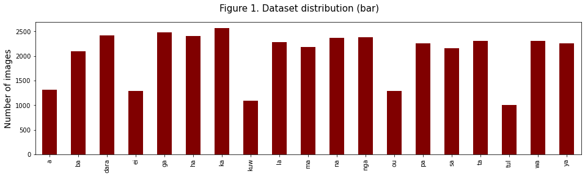

```python
# plot the dataset
fig, ax = plt.subplots(figsize=(16, 4))
dist.sort_index().plot(kind='bar', color='maroon')
plt.ylabel('Number of images', fontsize=14)
plt.suptitle('Figure 1. Dataset distribution (bar)', fontsize=15)
plt.show()
```

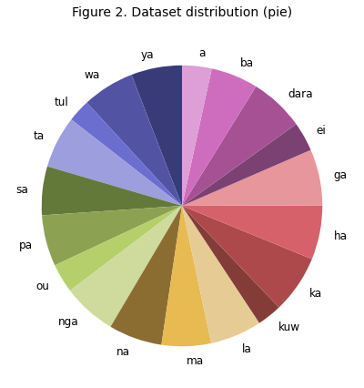

```python
# plot the pie chart of the dataset
fig, ax = plt.subplots(figsize=(6, 6))
dist.sort_index(ascending=False).plot(kind='pie', fontsize=12,
                                      startangle=90, cmap='tab20b')
plt.ylabel('')
plt.suptitle('Figure 2. Dataset distribution (pie)', fontsize=14)
plt.tight_layout()
plt.show()
```

Given the distribution of the 19 image classes, the team computed the Proportional Chance Criterion (PCC) as 5.596%, resulting in a target model accuracy of at least 6.996%, based on the heuristic of 1.25 multiplied by the PCC.

```python
print(f'PCC: {PCC:.3%}')
print(f'PCC x 1.25: {1.25*PCC:.3%}')
```

```
PCC: 5.596%
PCC x 1.25: 6.996%
```

The team also took a look at a sampling of images as well. Here are images of the 14 consonants. It may be observed that the images are closely cropped and of varying dimensions, ranging from about 50 to 100 pixels in height and width.

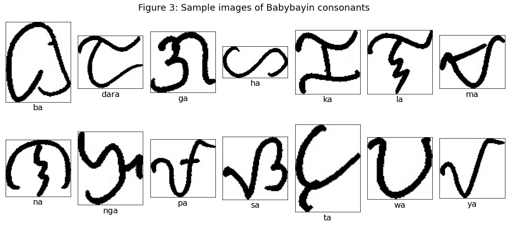

```python
img_list = ['ba/ba_00001_file001.jpg',
            'dara/dara_00001_file001.jpg',
            'ga/ga_00001_file001.jpg',
            'ha/ha_00001_file001.jpg',
            'ka/ka_00001_file001.jpg',
            'la/la_00001_file001.jpg',
            'ma/ma_00001_file001.jpg',
            'na/na_00001_file001.jpg',
            'nga/nga_00001_file001.jpg',
            'pa/pa_00001_file001.jpg',
            'sa/sa_00001_file001.jpg',
            'ta/ta_00001_file001.jpg',
            'wa/wa_00001_file001.jpg',
            'ya/ya_00001_file001.jpg']

labels = ['ba','dara', 'ga', 'ha', 'ka', 'la', 'ma',
          'na', 'nga', 'pa', 'sa', 'ta', 'wa', 'ya']


plt.figure(figsize = (14,12))
plt.suptitle("Figure 3: Sample images of Babybayin consonants", fontsize=18);
for idx, image_path in enumerate(img_list):
    plt.subplot(4, 7, idx + 1)
    img = Image.open(data_dir + image_path).convert('RGB')
    plt.imshow(img)
    #plt.axis('off')
    #plt.title(image_path.split('/')[1], fontsize=9)
    plt.xticks([])
    plt.yticks([])
    plt.xlabel(labels[idx], fontsize=16)
plt.tight_layout()
plt.show()
```

Displayed below are sample images of the vowels, and characters denoting punctuation or pauses:

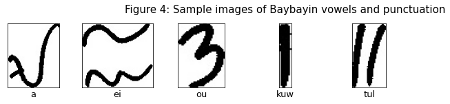

```python
img_list = ['a/a_00001_file001.jpg',
            'ei/ei_00001_file001.jpg',
            'ou/ou_00001_file001.jpg',
            'kuw/kuw_00003_file002.jpg',
            'tul/tul_00003_file002.jpg']
labels = ['a','ei', 'ou', 'kuw', 'tul']
plt.figure(figsize = (12, 7))
plt.suptitle("Figure 4: Sample images of Baybayin vowels and punctuation", fontsize=15);
for idx, image_path in enumerate(img_list):
    plt.subplot(4, 7, idx + 1)
    img = Image.open(data_dir + image_path).convert('RGB')
    plt.imshow(img)
    plt.xticks([])
    plt.yticks([])
    plt.xlabel(labels[idx], fontsize=13)
    #plt.title(image_path.split('/')[1], fontsize=9)
    plt.subplots_adjust(left  = 0.125,
                        right = 0.9,
                        bottom = 0.1,
                        top = 0.9,
                        wspace = 0.2,
                        hspace = 0.2)
plt.tight_layout()
plt.show()
```

Having examined the images, data augmentation was performed to allow for slight shifts in rotation, scale, brightness, and shear of the images to help the trained models become more robust. All images were also scaled to 64x64 for uniformity of input for each of the deep learning models.

`DirectoryIterator` objects were then built to allow for training of the various deep learning architectures using Tensorflow. Different iterators were constructed for the models loaded from Keras to account for the pre-processing functions already incporporated as a model layer during compilation.

```python
# For Baseline CNN and CoAtNet:
# With scaling to 1/255

train_datagen = ImageDataGenerator(rescale=1./255,
                                   validation_split=val_split,
                                   preprocessing_function=None,
                                   rotation_range=20,
                                   width_shift_range=0.2,
                                   height_shift_range=0.2,
                                   brightness_range=[0.7, 1.3],
                                   shear_range=0.2,
                                   zoom_range=0.2,
                                   channel_shift_range=0.7,
                                   horizontal_flip=False,
                                   vertical_flip=False,)

val_datagen = ImageDataGenerator(rescale=1./255,
                                 validation_split=val_split)


# Load data and turn into batches
train_data = train_datagen.flow_from_directory(data_dir,
                                               subset="training",
                                               target_size=(size, size),
                                               batch_size=batch_size,
                                               class_mode="categorical",
                                               seed=seed)

val_data = val_datagen.flow_from_directory(data_dir,
                                           subset="validation",
                                           target_size=(size, size),
                                           batch_size=batch_size,
                                           class_mode="categorical",
                                           seed=seed)
```

```
Found 28806 images belonging to 19 classes.
Found 9592 images belonging to 19 classes.
```

```python
# For Keras Models (VGG16, EfficientNet, ResNet):
# Without scaling to 1/255, since this is already incorporated into
# pre-processing steps built as layer during model compilation

keras_train_datagen = ImageDataGenerator(validation_split=val_split,
                                   preprocessing_function=None,
                                   rotation_range=20,
                                   width_shift_range=0.2,
                                   height_shift_range=0.2,
                                   brightness_range=[0.7, 1.3],
                                   shear_range=0.2,
                                   zoom_range=0.2,
                                   channel_shift_range=0.7,
                                   horizontal_flip=False,
                                   vertical_flip=False,)

keras_val_datagen = ImageDataGenerator(validation_split=val_split)


# Load data and turn into batches
keras_train_data = keras_train_datagen.flow_from_directory(data_dir,
                                               subset="training",
                                               target_size=(size, size),
                                               batch_size=batch_size,
                                               class_mode="categorical",
                                               seed=seed)

keras_val_data = keras_val_datagen.flow_from_directory(data_dir,
                                           subset="validation",
                                           target_size=(size, size),
                                           batch_size=batch_size,
                                           class_mode="categorical",
                                           seed=seed)
```

```
Found 28806 images belonging to 19 classes.
Found 9592 images belonging to 19 classes.
```

## IX. Results and Discussion

### 9.1 Models

A baseline CNN model was first explored, and the improved by looking at other pre-trained models such as VGG-16, ResNet50, EfficientNetB0 and state-of-the-art CoAtNet0. The model with the highest accuracy was selected and then deployed.

#### 9.1.1 CNN

A baseline CNN model was created so that it will serve as the baseline of comparison on the performance of the pre-trained architectures. Here, the CNN model is a basic CNN. The base CNN model has a total parameter count of 13,735.

```python
tf.keras.backend.clear_session()
gc.collect()
```

```python
base_cnn = models.Sequential()

base_cnn.add(layers.Conv2D(filters=4, kernel_size=3, strides=1,
                           padding='same',
                           input_shape=(size, size, 3)))
base_cnn.add(layers.BatchNormalization(axis=3))
base_cnn.add(layers.Activation('relu'))
base_cnn.add(layers.MaxPooling2D(pool_size=(2, 2)))

base_cnn.add(layers.Conv2D(filters=4, kernel_size=3, strides=1,
                           padding='same',
                           activation='relu'))
base_cnn.add(layers.MaxPooling2D(pool_size=(3, 3)))

base_cnn.add(layers.Flatten())
base_cnn.add(layers.Dense(32, activation="relu"))
base_cnn.add(layers.Dropout(0.6))

base_cnn.add(layers.Dense(num_labels, activation='softmax'))
base_cnn.summary()


base_cnn.compile(loss='categorical_crossentropy',
                 optimizer=optimizers.Adam(learning_rate=0.001),
                 metrics=['accuracy'])
```

```
Model: "sequential"
_________________________________________________________________
Layer (type)                 Output Shape              Param #
=================================================================
conv2d (Conv2D)              (None, 64, 64, 4)         112
_________________________________________________________________
batch_normalization (BatchNo (None, 64, 64, 4)         16
_________________________________________________________________
activation (Activation)      (None, 64, 64, 4)         0
_________________________________________________________________
max_pooling2d (MaxPooling2D) (None, 32, 32, 4)         0
_________________________________________________________________
conv2d_1 (Conv2D)            (None, 32, 32, 4)         148
_________________________________________________________________
max_pooling2d_1 (MaxPooling2 (None, 10, 10, 4)         0
_________________________________________________________________
flatten (Flatten)            (None, 400)               0
_________________________________________________________________
dense (Dense)                (None, 32)                12832
_________________________________________________________________
dropout (Dropout)            (None, 32)                0
_________________________________________________________________
dense_1 (Dense)              (None, 19)                627
=================================================================
Total params: 13,735
Trainable params: 13,727
Non-trainable params: 8
_________________________________________________________________
```

```python
%%time

filepath_cnn = save_dir + "/base_cnn_wts.hdf5"
checkpoint_cnn = ModelCheckpoint(filepath_cnn, monitor='val_accuracy',
                             verbose=1, save_best_only=True, mode='max')
reduce_lr_cnn = ReduceLROnPlateau(monitor='val_loss', factor=0.2,
                                  patience=2, min_lr=0.00001, verbose=1)
earlystop_cnn = EarlyStopping(monitor='val_accuracy', patience=5,
                              verbose=1)


base_cnn_history = base_cnn.fit(
    train_data,
    epochs=epochs,
    steps_per_epoch=steps_per_epoch,
    validation_steps=validation_steps,
    validation_data=val_data,
    callbacks=[checkpoint_cnn, reduce_lr_cnn, earlystop_cnn]
)
```

```
Epoch 00001: val_accuracy improved from -inf to 0.62719, saving model to ./savefiles/base_cnn_wts.hdf5

Epoch 00002: val_accuracy improved from 0.62719 to 0.76814, saving model to ./savefiles/base_cnn_wts.hdf5

Epoch 00003: val_accuracy improved from 0.76814 to 0.78086, saving model to ./savefiles/base_cnn_wts.hdf5

Epoch 00004: val_accuracy improved from 0.78086 to 0.78367, saving model to ./savefiles/base_cnn_wts.hdf5

Epoch 00005: val_accuracy improved from 0.78367 to 0.80922, saving model to ./savefiles/base_cnn_wts.hdf5

Epoch 00006: val_accuracy did not improve from 0.80922

Epoch 00007: val_accuracy did not improve from 0.80922

Epoch 00008: val_accuracy did not improve from 0.80922

Epoch 00009: val_accuracy improved from 0.80922 to 0.80942, saving model to ./savefiles/base_cnn_wts.hdf5

Epoch 00010: val_accuracy did not improve from 0.80942

Epoch 00011: val_accuracy improved from 0.80942 to 0.81224, saving model to ./savefiles/base_cnn_wts.hdf5

Epoch 00011: ReduceLROnPlateau reducing learning rate to 0.00020000000949949026.

Epoch 00012: val_accuracy improved from 0.81224 to 0.81610, saving model to ./savefiles/base_cnn_wts.hdf5

Epoch 00013: val_accuracy improved from 0.81610 to 0.82663, saving model to ./savefiles/base_cnn_wts.hdf5

Epoch 00014: val_accuracy improved from 0.82663 to 0.83007, saving model to ./savefiles/base_cnn_wts.hdf5

Epoch 00015: val_accuracy did not improve from 0.83007

Epoch 00016: val_accuracy did not improve from 0.83007

Epoch 00016: ReduceLROnPlateau reducing learning rate to 4.0000001899898055e-05.

Epoch 00017: val_accuracy did not improve from 0.83007

Epoch 00018: val_accuracy did not improve from 0.83007

Epoch 00019: val_accuracy improved from 0.83007 to 0.83142, saving model to ./savefiles/base_cnn_wts.hdf5

Epoch 00020: val_accuracy did not improve from 0.83142

Epoch 00021: val_accuracy did not improve from 0.83142

Epoch 00022: val_accuracy did not improve from 0.83142

Epoch 00022: ReduceLROnPlateau reducing learning rate to 1e-05.

Epoch 00023: val_accuracy did not improve from 0.83142

Epoch 00024: val_accuracy did not improve from 0.83142
Epoch 00024: early stopping
CPU times: user 37min 39s, sys: 3min 16s, total: 40min 55s
Wall time: 46min 18s
```

```python
def plot_results(history):
    fig, (ax1, ax2) = plt.subplots(1, 2, figsize=(15,5))

    # plot accuracy
    acc = history.history['accuracy']
    val_acc = history.history['val_accuracy']
    epochs = range(1, len(acc) + 1)

    ax1.plot(epochs, acc, 'ko', label='Training acc')
    ax1.plot(epochs, val_acc, 'k', label='Validation acc')
    ax1.set_title('Training and validation accuracy')
    ax1.set_xlabel('Epochs')
    ax1.legend()

    # plot loss
    loss = history.history['loss']
    val_loss = history.history['val_loss']

    ax2.plot(epochs, loss, 'ro', label='Training loss')
    ax2.plot(epochs, val_loss, 'r', label='Validation loss')
    ax2.set_title('Training and validation loss')
    ax2.set_xlabel('Epochs')
    ax2.legend()
```

```python
base_cnn.load_weights(filepath_cnn)

base_cnn.save(save_dir + '/base_cnn.h5')

import pickle
with open(save_dir + '/base_cnn_hist.pickle', 'wb') as handle:
    pickle.dump(base_cnn_history.history, handle,
                protocol=pickle.HIGHEST_PROTOCOL)
```

**Figure 5. Training plots for the baseline CNN model**

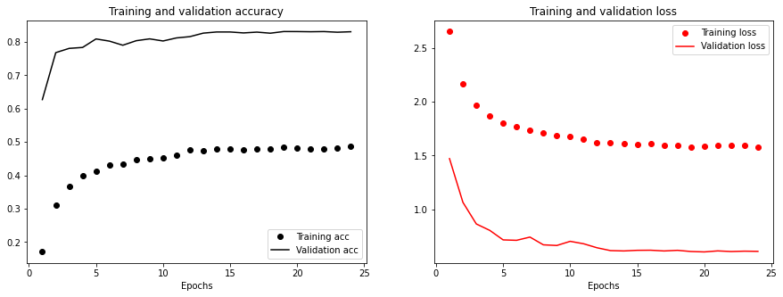

```python
plot_results(base_cnn_history)
```

From the training plots, it may be observed that the validation accuracy and loss were better than those for the training set. This is an indication that the CNN model was good at generalizing, although it still converged too early at about 83% validation accuracy.

#### 9.1.2 VGG16

`VGG16` is a convolutional neural network model proposed by K. Simonyan and A. Zisserman from the University of Oxford in the paper “Very Deep Convolutional Networks for Large-Scale Image Recognition”. It is a CNN architecture that won the ImageNet Large Scale Visual Recognition Challenge in 2014. It is currently ranked `495th` in Image Classification on ImageNet leaderboard.

**Figure 6. VGG-16 Network Architecture**

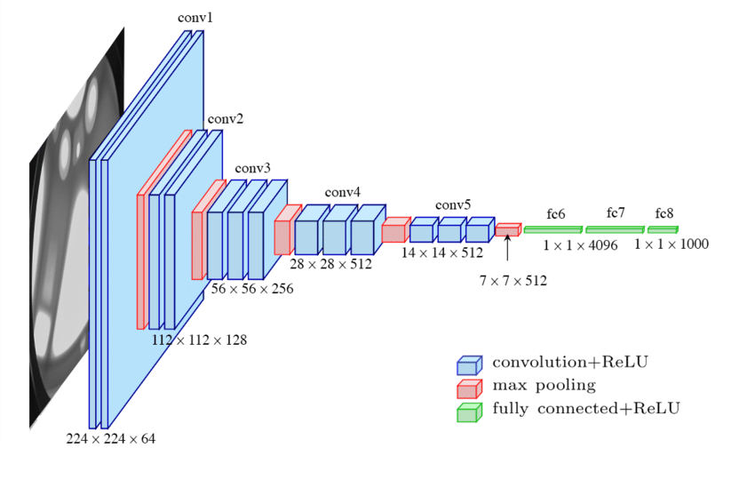

```python
tf.keras.backend.clear_session()
gc.collect()
```

```python
from tensorflow.keras.applications.vgg16 import preprocess_input as preprocess_vgg16

vgg16 = tf.keras.applications.VGG16(weights=None,
                  include_top=False)

model_vgg16 = models.Sequential()
model_vgg16.add(layers.Lambda(preprocess_vgg16,
                             input_shape=(size, size, 3)))
model_vgg16.add(vgg16)
model_vgg16.add(layers.Flatten())
model_vgg16.add(layers.Dense(num_labels, activation='softmax'))

model_vgg16.summary()

model_vgg16.compile(loss='categorical_crossentropy',
                   optimizer=optimizers.Adam(learning_rate=0.0001),
                   metrics=['accuracy'])
```

```
Model: "sequential"
_________________________________________________________________
Layer (type)                 Output Shape              Param #
=================================================================
lambda (Lambda)              (None, 64, 64, 3)         0
_________________________________________________________________
vgg16 (Functional)           (None, None, None, 512)   14714688
_________________________________________________________________
flatten (Flatten)            (None, 2048)              0
_________________________________________________________________
dense (Dense)                (None, 19)                38931
=================================================================
Total params: 14,753,619
Trainable params: 14,753,619
Non-trainable params: 0
_________________________________________________________________
```

```python
%%time

filepath_vgg = save_dir + "/base_vgg_wts_v2.hdf5"
checkpoint_vgg = ModelCheckpoint(filepath_vgg, monitor='val_accuracy',
                             verbose=1, save_best_only=True, mode='max')
reduce_lr_vgg = ReduceLROnPlateau(monitor='val_loss', factor=0.2,
                              patience=2, min_lr=0.000001, verbose=1)
earlystop_vgg = EarlyStopping(monitor='val_accuracy', patience=5,
                              verbose=1)


vgg_history = model_vgg16.fit(
    keras_train_data,
    epochs=epochs,
    steps_per_epoch=steps_per_epoch,
    validation_steps=validation_steps,
    validation_data=keras_val_data,
    callbacks=[checkpoint_vgg, reduce_lr_vgg, earlystop_vgg]
)
```

```
Epoch 00001: val_accuracy improved from -inf to 0.94610, saving model to ./savefiles/base_vgg_wts_v2.hdf5

Epoch 00002: val_accuracy improved from 0.94610 to 0.95830, saving model to ./savefiles/base_vgg_wts_v2.hdf5

Epoch 00003: val_accuracy did not improve from 0.95830

Epoch 00004: val_accuracy did not improve from 0.95830

Epoch 00005: val_accuracy did not improve from 0.95830

Epoch 00006: val_accuracy improved from 0.95830 to 0.96820, saving model to ./savefiles/base_vgg_wts_v2.hdf5

Epoch 00007: val_accuracy improved from 0.96820 to 0.96966, saving model to ./savefiles/base_vgg_wts_v2.hdf5

Epoch 00008: val_accuracy improved from 0.96966 to 0.97070, saving model to ./savefiles/base_vgg_wts_v2.hdf5

Epoch 00009: val_accuracy did not improve from 0.97070

Epoch 00010: val_accuracy did not improve from 0.97070

Epoch 00010: ReduceLROnPlateau reducing learning rate to 1.9999999494757503e-05.

Epoch 00011: val_accuracy improved from 0.97070 to 0.97654, saving model to ./savefiles/base_vgg_wts_v2.hdf5

Epoch 00012: val_accuracy improved from 0.97654 to 0.98050, saving model to ./savefiles/base_vgg_wts_v2.hdf5

Epoch 00013: val_accuracy improved from 0.98050 to 0.98363, saving model to ./savefiles/base_vgg_wts_v2.hdf5

Epoch 00014: val_accuracy did not improve from 0.98363

Epoch 00015: val_accuracy did not improve from 0.98363

Epoch 00015: ReduceLROnPlateau reducing learning rate to 3.999999898951501e-06.

Epoch 00016: val_accuracy did not improve from 0.98363

Epoch 00017: val_accuracy improved from 0.98363 to 0.98509, saving model to ./savefiles/base_vgg_wts_v2.hdf5

Epoch 00018: val_accuracy did not improve from 0.98509

Epoch 00019: val_accuracy did not improve from 0.98509

Epoch 00019: ReduceLROnPlateau reducing learning rate to 1e-06.

Epoch 00020: val_accuracy did not improve from 0.98509

Epoch 00021: val_accuracy did not improve from 0.98509

Epoch 00022: val_accuracy did not improve from 0.98509
Epoch 00022: early stopping
CPU times: user 43min 4s, sys: 3min 5s, total: 46min 10s
Wall time: 42min 5s
```

```python
model_vgg16.load_weights(filepath_vgg)

model_vgg16.save(save_dir + '/vgg16_v2.h5')

with open(save_dir + '/vgg16_hist_v2.pickle', 'wb') as handle:
    pickle.dump(vgg_history.history, handle,
                protocol=pickle.HIGHEST_PROTOCOL)
```

**Figure 7. Training plots for the VGG16 model**

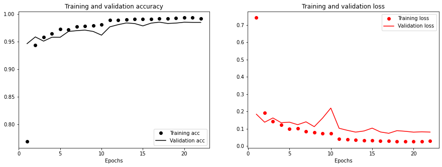

```python
plot_results(vgg_history)
```

For VGG16, the training plots are quite good, with validation accuracy continuing to improve in line with training accuracy, indicating minimal overfitting (although validation loss seemed to plateau). The best validation accuracy achieved was rather high, at 98.5%.

#### 9.1.3 ResNet50

ResNet was creatd witht he aim of tacklng the problem of degradation as the number of layers in the neural network increases. As neural networks become deeper, the accuracy levels may get saturated and slowly degrade after a point. This may result in the performance of the model to deteriotate on the training and desting data. ResNet makes use of residual blocks to improve the accuracy of the model. The skip connections in ResNet attempt to alleviate the vanishing gradient problem by setting up an alternate shortcut for the gradient to pass through.

**Figure 8. ResNet Network Architecture**

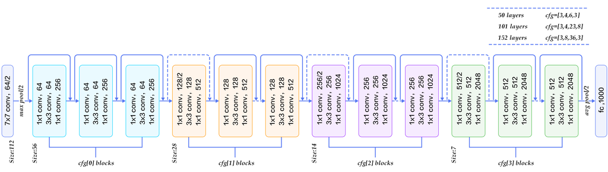

```python
tf.keras.backend.clear_session()
gc.collect()
```

```python
from tensorflow.keras.applications.resnet50 import preprocess_input as preprocess_res50

resnet50 = tf.keras.applications.ResNet50(
    include_top=False,
    weights=None)

model_res50 = models.Sequential()

model_res50.add(layers.Lambda(preprocess_res50,
                             input_shape=(size, size, 3)))
model_res50.add(resnet50)
model_res50.add(layers.Flatten())
# model_res50.add(layers.Dense(32, activation="relu"))
# model_effb0.add(layers.Dropout(0.6))
model_res50.add(layers.Dense(num_labels, activation='softmax'))

model_res50.summary()

model_res50.compile(loss='categorical_crossentropy',
                    optimizer=optimizers.Adam(learning_rate=0.0001),
                    metrics=['accuracy'])
```

```
Model: "sequential_1"
_________________________________________________________________
Layer (type)                 Output Shape              Param #
=================================================================
lambda_1 (Lambda)            (None, 64, 64, 3)         0
_________________________________________________________________
resnet50 (Functional)        (None, None, None, 2048)  23587712
_________________________________________________________________
flatten_1 (Flatten)          (None, 8192)              0
_________________________________________________________________
dense_2 (Dense)              (None, 19)                155667
=================================================================
Total params: 23,743,379
Trainable params: 23,690,259
Non-trainable params: 53,120
_________________________________________________________________
```

```python
%%time

filepath_res = save_dir + "/base_res_wts.hdf5"
checkpoint_res = ModelCheckpoint(filepath_res, monitor='val_accuracy',
                             verbose=1, save_best_only=True, mode='max')
reduce_lr_res = ReduceLROnPlateau(monitor='val_loss', factor=0.2,
                              patience=2, min_lr=0.000001, verbose=1)
earlystop_res = EarlyStopping(monitor='val_accuracy', patience=5,
                              verbose=1)


res_history = model_res50.fit(
    keras_train_data,
    epochs=epochs,
    steps_per_epoch=steps_per_epoch,
    validation_steps=validation_steps,
    validation_data=keras_val_data,
    callbacks=[checkpoint_res, reduce_lr_res, earlystop_res]
)
```

```
Epoch 00001: val_accuracy improved from -inf to 0.45131, saving model to ./savefiles/base_res_wts.hdf5

Epoch 00002: val_accuracy improved from 0.45131 to 0.66858, saving model to ./savefiles/base_res_wts.hdf5

Epoch 00003: val_accuracy improved from 0.66858 to 0.80984, saving model to ./savefiles/base_res_wts.hdf5

Epoch 00004: val_accuracy improved from 0.80984 to 0.83372, saving model to ./savefiles/base_res_wts.hdf5

Epoch 00005: val_accuracy improved from 0.83372 to 0.87709, saving model to ./savefiles/base_res_wts.hdf5

Epoch 00006: val_accuracy improved from 0.87709 to 0.88980, saving model to ./savefiles/base_res_wts.hdf5

Epoch 00007: val_accuracy improved from 0.88980 to 0.90857, saving model to ./savefiles/base_res_wts.hdf5

Epoch 00008: val_accuracy improved from 0.90857 to 0.91253, saving model to ./savefiles/base_res_wts.hdf5

Epoch 00009: val_accuracy improved from 0.91253 to 0.92056, saving model to ./savefiles/base_res_wts.hdf5

Epoch 00010: val_accuracy did not improve from 0.92056

Epoch 00011: val_accuracy improved from 0.92056 to 0.93745, saving model to ./savefiles/base_res_wts.hdf5

Epoch 00012: val_accuracy did not improve from 0.93745

Epoch 00013: val_accuracy did not improve from 0.93745

Epoch 00013: ReduceLROnPlateau reducing learning rate to 1.9999999494757503e-05.

Epoch 00014: val_accuracy improved from 0.93745 to 0.96810, saving model to ./savefiles/base_res_wts.hdf5

Epoch 00015: val_accuracy improved from 0.96810 to 0.97123, saving model to ./savefiles/base_res_wts.hdf5

Epoch 00016: val_accuracy did not improve from 0.97123

Epoch 00017: val_accuracy improved from 0.97123 to 0.97529, saving model to ./savefiles/base_res_wts.hdf5

Epoch 00018: val_accuracy did not improve from 0.97529

Epoch 00019: val_accuracy did not improve from 0.97529

Epoch 00019: ReduceLROnPlateau reducing learning rate to 3.999999898951501e-06.

Epoch 00020: val_accuracy improved from 0.97529 to 0.97717, saving model to ./savefiles/base_res_wts.hdf5

Epoch 00021: val_accuracy did not improve from 0.97717

Epoch 00022: val_accuracy did not improve from 0.97717

Epoch 00022: ReduceLROnPlateau reducing learning rate to 1e-06.

Epoch 00023: val_accuracy did not improve from 0.97717

Epoch 00024: val_accuracy did not improve from 0.97717

Epoch 00025: val_accuracy did not improve from 0.97717
Epoch 00025: early stopping
CPU times: user 59min 1s, sys: 3min 35s, total: 1h 2min 36s
Wall time: 47min 42s
```

```python
model_res50.load_weights(filepath_res)

model_res50.save(save_dir + '/res50.h5')

with open(save_dir + '/res50_hist.pickle', 'wb') as handle:
    pickle.dump(res_history.history, handle,
                protocol=pickle.HIGHEST_PROTOCOL)
```

**Figure 9. Training plots for the ResNet50 model**

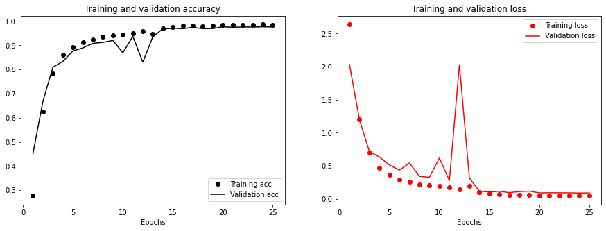

```python
plot_results(res_history)
```

#### 9.1.4 EfficientNetB0

`EfficientNet` is a convolutional neural network architecture and scaling approach that uses a compound coefficient to consistently scale all depth/width/resolution dimensions. Unlike traditional methodology, which arbitrarily scales these elements, the EfficientNet scaling approach evenly adjusts network width, depth, and resolution using a predetermined set of scaling coefficients. The `number of parameters` is lighter at around `4 million`, compared to other Deep Neural Network models like VGG-16, ResNet, among others (Tan and Le, 2019).

**Figure 10. EfficientNetB0 Network Architecture**

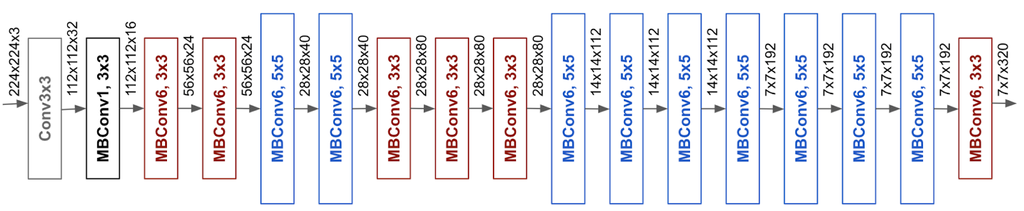

```python
tf.keras.backend.clear_session()
gc.collect()
```

```python
effnetb0 = tf.keras.applications.EfficientNetB0(
    include_top=False,
    weights=None,
    input_shape=(size, size, 3))

model_effb0 = models.Sequential()

model_effb0.add(effnetb0)
model_effb0.add(layers.Flatten())
# model_effb0.add(layers.Dense(32, activation="relu"))
# model_effb0.add(layers.Dropout(0.6))
model_effb0.add(layers.Dense(num_labels, activation='softmax'))

model_effb0.summary()

model_effb0.compile(loss='categorical_crossentropy',
                    optimizer=optimizers.Adam(learning_rate=0.0001),
                    metrics=['accuracy'])
```

```
Model: "sequential"
_________________________________________________________________
Layer (type)                 Output Shape              Param #
=================================================================
efficientnetb0 (Functional)  (None, 2, 2, 1280)        4049571
_________________________________________________________________
flatten (Flatten)            (None, 5120)              0
_________________________________________________________________
dense (Dense)                (None, 19)                97299
=================================================================
Total params: 4,146,870
Trainable params: 4,104,847
Non-trainable params: 42,023
_________________________________________________________________
```

```python
%%time

filepath_eff = save_dir + "/base_eff_wts.hdf5"
checkpoint_eff = ModelCheckpoint(filepath_eff, monitor='val_accuracy',
                             verbose=1, save_best_only=True, mode='max')
reduce_lr_eff = ReduceLROnPlateau(monitor='val_loss', factor=0.2,
                              patience=2, min_lr=0.000001, verbose=1)
earlystop_eff = EarlyStopping(monitor='val_accuracy', patience=5,
                              verbose=1)


eff_history = model_effb0.fit(
    keras_train_data,
    epochs=epochs,
    steps_per_epoch=steps_per_epoch,
    validation_steps=validation_steps,
    validation_data=keras_val_data,
    callbacks=[checkpoint_eff, reduce_lr_eff, earlystop_eff]
)
```

```
Epoch 00001: val_accuracy improved from -inf to 0.10457, saving model to ./savefiles/base_eff_wts.hdf5

Epoch 00002: val_accuracy improved from 0.10457 to 0.18599, saving model to ./savefiles/base_eff_wts.hdf5

Epoch 00003: val_accuracy improved from 0.18599 to 0.38324, saving model to ./savefiles/base_eff_wts.hdf5

Epoch 00004: val_accuracy improved from 0.38324 to 0.53034, saving model to ./savefiles/base_eff_wts.hdf5

Epoch 00005: val_accuracy improved from 0.53034 to 0.69975, saving model to ./savefiles/base_eff_wts.hdf5

Epoch 00006: val_accuracy improved from 0.69975 to 0.76814, saving model to ./savefiles/base_eff_wts.hdf5

Epoch 00007: val_accuracy improved from 0.76814 to 0.81578, saving model to ./savefiles/base_eff_wts.hdf5

Epoch 00008: val_accuracy improved from 0.81578 to 0.85696, saving model to ./savefiles/base_eff_wts.hdf5

Epoch 00009: val_accuracy improved from 0.85696 to 0.87667, saving model to ./savefiles/base_eff_wts.hdf5

Epoch 00010: val_accuracy improved from 0.87667 to 0.90575, saving model to ./savefiles/base_eff_wts.hdf5

Epoch 00011: val_accuracy did not improve from 0.90575

Epoch 00012: val_accuracy did not improve from 0.90575

Epoch 00012: ReduceLROnPlateau reducing learning rate to 1.9999999494757503e-05.

Epoch 00013: val_accuracy improved from 0.90575 to 0.91816, saving model to ./savefiles/base_eff_wts.hdf5

Epoch 00014: val_accuracy improved from 0.91816 to 0.91972, saving model to ./savefiles/base_eff_wts.hdf5

Epoch 00015: val_accuracy improved from 0.91972 to 0.92077, saving model to ./savefiles/base_eff_wts.hdf5

Epoch 00016: val_accuracy improved from 0.92077 to 0.92358, saving model to ./savefiles/base_eff_wts.hdf5

Epoch 00017: val_accuracy improved from 0.92358 to 0.92389, saving model to ./savefiles/base_eff_wts.hdf5

Epoch 00018: val_accuracy did not improve from 0.92389

Epoch 00019: val_accuracy improved from 0.92389 to 0.92650, saving model to ./savefiles/base_eff_wts.hdf5

```

[output cut: 12 more lines]

```
Epoch 00025: val_accuracy improved from 0.92963 to 0.93005, saving model to ./savefiles/base_eff_wts.hdf5

Epoch 00025: ReduceLROnPlateau reducing learning rate to 1e-06.

Epoch 00026: val_accuracy did not improve from 0.93005

Epoch 00027: val_accuracy improved from 0.93005 to 0.93036, saving model to ./savefiles/base_eff_wts.hdf5

Epoch 00028: val_accuracy did not improve from 0.93036

Epoch 00029: val_accuracy did not improve from 0.93036

Epoch 00030: val_accuracy did not improve from 0.93036
CPU times: user 1h 20min 18s, sys: 5min 4s, total: 1h 25min 23s
Wall time: 58min 42s
```

```python
model_effb0.load_weights(filepath_eff)

model_effb0.save(save_dir + '/effb0.h5')

with open(save_dir + '/effb0_hist.pickle', 'wb') as handle:
    pickle.dump(eff_history.history, handle,
                protocol=pickle.HIGHEST_PROTOCOL)
```

**Figure 11. Training plots for the EfficientNetB0 model**

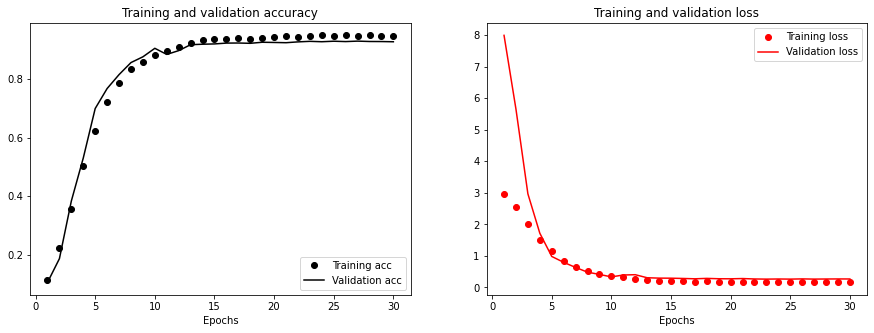

```python
plot_results(eff_history)
```

The training plots for EfficientNetB0 show the model was tuned very well to avoid overfitting, with the performance during validation almost identical to training performance throughout training. Still, the model converged sooner than it did for VGG16, with 93.0% being the best validation accuracy achieved.

#### 9.1.5 CoAtNet0

CoAtNet is the product of marrying `convolution` and `transformer models`. CoAtNet enjoys both good generalization like ConvNets and superior model capacity like Transformers, achieving state-of-the-art performances under different data sizes and computation budgets. CoAtNet was trained from ImageNet21k (12.7M images) and JFT (300M images) and then fine tuned on ImageNet-1K (1.3M images).

What was used in this project is CoAtNet-0, having 23 million parameters. It is the first version of CoAtNet. This study also attempted to use CoAtNet-4 with 275 million parameters, however, the training time was too long, with a single epoch about an hour to complete.

Currently the upgraded version of CoAtNet, which is CoAtNet-7 is `ranked 1st` in the Image Classification on ImageNet leaderboard.

The difference between CoAtNet-0 and CoAtNet-7 are the number of blocks and hidden dimensions or number of channels.

**Figure 12: CoAtNet0 Network Architecture**

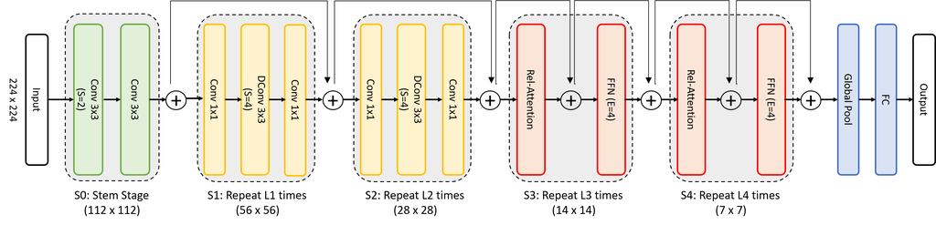

```python
tf.keras.backend.clear_session()
gc.collect()
```

```python
coatnet0 = keras_cv_attention_models.coatnet.CoAtNet0(num_classes=0,
                                                      pretrained=None,
                                                      input_shape=(size,
                                                                   size,
                                                                   3))

model_coat0 = models.Sequential()

model_coat0.add(coatnet0)
model_coat0.add(layers.Flatten())
# model_coat0.add(layers.Dense(32, activation="relu"))
# model_coat0.add(layers.Dropout(0.6))
model_coat0.add(layers.Dense(num_labels, activation='softmax'))

model_coat0.summary()

model_coat0.compile(loss='categorical_crossentropy',
                   optimizer=optimizers.Adam(learning_rate=0.0001),
                   metrics=['accuracy'])
```

```
Model: "sequential_1"
_________________________________________________________________
Layer (type)                 Output Shape              Param #
=================================================================
coatnet0 (Functional)        (None, 2, 2, 768)         23032698
_________________________________________________________________
flatten_1 (Flatten)          (None, 3072)              0
_________________________________________________________________
dense_1 (Dense)              (None, 19)                58387
=================================================================
Total params: 23,091,085
Trainable params: 23,079,437
Non-trainable params: 11,648
_________________________________________________________________
```

```python
%%time

filepath_coat = save_dir + "/base_coat_wts.hdf5"
checkpoint_coat = ModelCheckpoint(filepath_coat, monitor='val_accuracy',
                             verbose=1, save_best_only=True, mode='max')
reduce_lr_coat = ReduceLROnPlateau(monitor='val_loss', factor=0.2,
                              patience=2, min_lr=0.000001, verbose=1)
earlystop_coat= EarlyStopping(monitor='val_accuracy', patience=5,
                              verbose=1)


coat_history = model_coat0.fit(
    keras_train_data,
    epochs=epochs,
    steps_per_epoch=steps_per_epoch,
    validation_steps=validation_steps,
    validation_data=keras_val_data,
    callbacks=[checkpoint_coat, reduce_lr_coat, earlystop_coat]
)
```

```
Epoch 00001: val_accuracy improved from -inf to 0.82475, saving model to ./savefiles/base_coat_wts.hdf5
```

```
Epoch 00002: val_accuracy improved from 0.82475 to 0.86374, saving model to ./savefiles/base_coat_wts.hdf5

Epoch 00003: val_accuracy improved from 0.86374 to 0.88636, saving model to ./savefiles/base_coat_wts.hdf5

Epoch 00004: val_accuracy improved from 0.88636 to 0.89835, saving model to ./savefiles/base_coat_wts.hdf5

Epoch 00005: val_accuracy improved from 0.89835 to 0.92807, saving model to ./savefiles/base_coat_wts.hdf5

Epoch 00006: val_accuracy improved from 0.92807 to 0.93693, saving model to ./savefiles/base_coat_wts.hdf5

Epoch 00007: val_accuracy improved from 0.93693 to 0.94151, saving model to ./savefiles/base_coat_wts.hdf5

Epoch 00008: val_accuracy did not improve from 0.94151

Epoch 00009: val_accuracy did not improve from 0.94151

Epoch 00009: ReduceLROnPlateau reducing learning rate to 1.9999999494757503e-05.

Epoch 00010: val_accuracy improved from 0.94151 to 0.95892, saving model to ./savefiles/base_coat_wts.hdf5

Epoch 00011: val_accuracy did not improve from 0.95892

Epoch 00012: val_accuracy did not improve from 0.95892

Epoch 00012: ReduceLROnPlateau reducing learning rate to 3.999999898951501e-06.

Epoch 00013: val_accuracy improved from 0.95892 to 0.96101, saving model to ./savefiles/base_coat_wts.hdf5

Epoch 00014: val_accuracy improved from 0.96101 to 0.96122, saving model to ./savefiles/base_coat_wts.hdf5

Epoch 00015: val_accuracy improved from 0.96122 to 0.96497, saving model to ./savefiles/base_coat_wts.hdf5

Epoch 00016: val_accuracy improved from 0.96497 to 0.96591, saving model to ./savefiles/base_coat_wts.hdf5

Epoch 00017: val_accuracy did not improve from 0.96591

Epoch 00018: val_accuracy improved from 0.96591 to 0.96612, saving model to ./savefiles/base_coat_wts.hdf5

Epoch 00019: val_accuracy did not improve from 0.96612

```

[output cut: 10 more lines]

```
Epoch 00024: val_accuracy did not improve from 0.96643

Epoch 00025: val_accuracy improved from 0.96643 to 0.96664, saving model to ./savefiles/base_coat_wts.hdf5

Epoch 00026: val_accuracy did not improve from 0.96664

Epoch 00027: val_accuracy did not improve from 0.96664

Epoch 00028: val_accuracy improved from 0.96664 to 0.96747, saving model to ./savefiles/base_coat_wts.hdf5

Epoch 00029: val_accuracy did not improve from 0.96747

Epoch 00030: val_accuracy did not improve from 0.96747
CPU times: user 1h 31min 34s, sys: 5min 32s, total: 1h 37min 7s
Wall time: 59min 13s
```

```python
model_coat0.load_weights(filepath_coat)

model_coat0.save(save_dir + '/coat0.h5')

with open(save_dir + '/coat0_hist.pickle', 'wb') as handle:
    pickle.dump(coat_history.history, handle, protocol=pickle.HIGHEST_PROTOCOL)
```

**Figure 13. Training plots for the CoAtNet0 model**

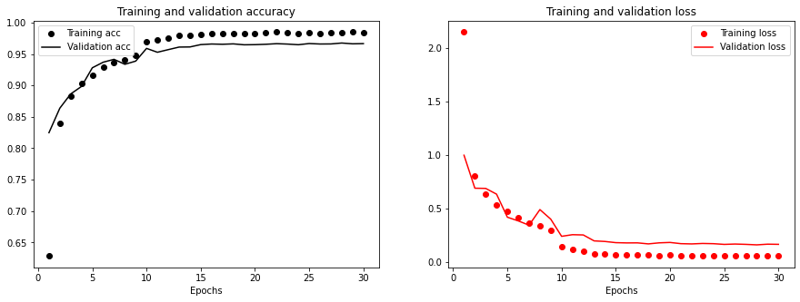

```python
plot_results(base_coat_history)
```

The training plots for CoAtNet still appear quite good, although the overfitting is more apparent compared to the previous models attempted, with the validation performance slightly below than traiing performance from around the 10th epoch onwards, and visibly plateauing starting around epoch 15. Still, the final performance was still respectable at 96.75% validation accuracy.

### 9.2 Model Selection and Testing on Unseen Images

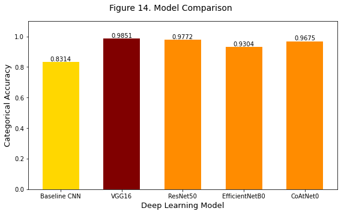

```python
models = ['Baseline CNN', 'VGG16', 'ResNet50', 'EfficientNetB0', 'CoAtNet0']
scores = [.8314, .9851, .9772, .9304, .9675]
model_eval = pd.Series(scores, index=models)

fig, ax = plt.subplots(figsize=(8, 5))

pps = ax.bar(model_eval.index, model_eval.values, width=0.6,
             color=['gold', 'maroon', 'darkorange',
                    'darkorange', 'darkorange'])

for p in pps:
    height = p.get_height()
    ax.annotate('{}'.format(height),
      xy=(p.get_x() + p.get_width() / 2, height),
      xytext=(0, 0), # vertical offset
      textcoords="offset points",
      ha='center', va='bottom')

plt.ylim(0, 1.1)
plt.ylabel('Categorical Accuracy', fontsize=13)
plt.xlabel('Deep Learning Model', fontsize=13)
plt.suptitle('Figure 14. Model Comparison', fontsize=14)
plt.xticks(rotation='horizontal')
plt.tight_layout()
plt.show()
```

Given that VGG16 had the best performance, this was chosen as the preferred model for deployment.

To demonstrate on a small test set of unseen images and provide some indication of the model's performance upon deployment, the team used their own handwriting to manually depict various baybayin characters. Images of these handwritten characters, as well as the corresponding model predictions, are shown below.

```python
model = tf.keras.models.load_model(save_dir + 'vgg16_v2.h5')
```

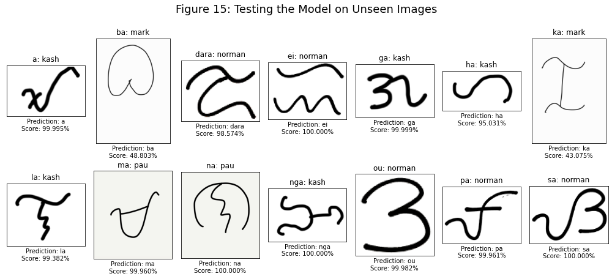

```python
test_dir = '/mnt/processed/private/msds2022/cpt11/ML3/Baybayin-Handwritten-Character-Dataset/test/'
save_dir = '/mnt/processed/private/msds2022/cpt11/ML3/Baybayin-Handwritten-Character-Dataset/savefiles/'

df_sample = pd.read_csv(save_dir + 'predictions.csv').sample(60)
df_sample['path'] = test_dir + df_sample['letter'] + '/' + df_sample['file']
df_sample = df_sample.drop_duplicates('letter')
df_sample = df_sample.sort_values('letter')
df_sample = df_sample.reset_index(drop=True)
df_sample = df_sample.iloc[:14]

plt.figure(figsize = (14,12))
plt.suptitle("Figure 15: Testing the Model on Unseen Images\n", fontsize=18);
for idx, image_path in enumerate((df_sample['path'])):
    plt.subplot(4, 7, idx + 1)
    img = Image.open(image_path).convert('RGB')
    plt.imshow(img)
    plt.xticks([])
    plt.yticks([])
    plt.title(f"{df_sample['letter'].iloc[idx]}: {df_sample['member'].iloc[idx]}")
    plt.xlabel(f"Prediction: {df_sample['predictions'].iloc[idx]}\n"
               f"Score: {df_sample['prob'].iloc[idx]:.3%}")
plt.tight_layout()
plt.show()
```

It was found that the VGG16 model was indeed able to classify the images correctly, mostly with a high degree of confidence. Although it was also observed that the prediction scores become noticeably lower when the pen thickness is narrow, or when the images are not closely cropped, as was characteristic of the training set. This represents some opportunity to make the model more generalizeable by introducing more variation in the training data.

To deploy the model on new images, the team undertook to implement a real-time Optical Character Recognition Model, as demonstrated below.

### 9.3 Optical Character Recognition Deployment on Video

The researchers made a real-time OCR Baybayin recognition tool using `OpenCV`. The webcam or any USB camera connected to a computer can be used, or a video taken from a mobile phone can be uploaded using the codes below. The video format can be any of the popular video formats, but only .mov and .mp4 files were used for this study.

The threshold to display a prediction was set at 90%, but this tolerance can be set by the user.

```python
# Set the input type, either a video file or a live webcam.
# Comment out the input type that will not be used.
# Note: this will only run on a local PC!!!

# If using a video file:
video = './OpenCV/ka_dara_nga_na.mp4'

# If using a webcam:
video = 0
```

```python
cap = cv2.VideoCapture(video)

if not cap.isOpened():
    print("Error loading the video file or camera")
    exit()

width = 640
height = 480
cap.set(3, width)
cap.set(4, height)

time_start = time.time()

while True:
    try:
        success, imgOriginal = cap.read()
        img = cv2.resize(imgOriginal, (64, 64))
        img = np.expand_dims(img, axis=0)

        #predict
        predictions = model.predict(img)
        pred_label = label_dict[np.argmax(predictions)]
        probVal = np.amax(predictions)

        threshold = 0.90
        if probVal > threshold:
            cv2.putText(img=imgOriginal, text=pred_label + ': ' + str(probVal),
                        org=(100, 100), fontFace=cv2.FONT_HERSHEY_COMPLEX,
                        fontScale=3, color=(255,255,0), thickness=3)
            print(pred_label, probVal)
        else:
            cv2.putText(img=imgOriginal, text='Unable to predict',
                        org=(100, 100), fontFace=cv2.FONT_HERSHEY_COMPLEX,
                        fontScale=3, color=(255,255,0), thickness=3)
#             print(pred_label, probVal)

        cv2.imshow('BaybAIyin Predictor', imgOriginal)

        time_now = time.time()
        num_seconds = time_now - time_start
        if num_seconds > 90:
            print('Time is up.')
            break

    except:
        print('Error: Closing camera')
        success = False
        cap.release()
        cv2.destroyAllWindows()
        break

    if (cv2.waitKey(1) & 0xFF == ord('q')):
        print('Camera or video closed by user')
        success = False
        cap.release()
        cv2.destroyAllWindows()
        break

    if not success:
        print('Failed to capture image')
        cap.release()
        cv2.destroyAllWindows()
        break


cap.release()
cv2.destroyAllWindows()
print('End of video')
```

The following shows the resulting predictions and the corresponding prediction score overlaid on a video taken of various baybayin characters recorded using a mobile phone camera.

**Figure 16: Video Demo of OCR Deployment**

```python
from IPython.display import HTML

HTML("""
<center><video width="640" height="480" controls>
  <source src="baybayin3_demo.mp4" type="video/mp4">
</video></center>
""")
```

[video not shown]

## X. Conclusion

This study demonstrated how deep learning can be used to further the Filipino heritage by classifying Baybayin using a base CNN and newer models such as VGG16, Resnet50, EfficientNetB0 and CoAtNet. The best performing model was VGG16 at 98.5% accuracy. Comparing our studies to the Image Classification on EMNIST-Letters shows that we are able to achieve comparable accuracy, with the highest accuracy in https://paperswithcode.com/sota/image-classification-on-emnist-letters at 95.88%.

There is value in our past, just as older models can outperform newer state of the art neural networks. This sstudy also demonstrated that using the appropriate model for a problem is important. The results show that 8-year old VGG16 beat the newer, state-of-the-art CoAtNet model.

The results of this study can be used by linguists, historians and researchers to help them transliterate and study baybayin text faster, and help revive a language, making it more accessible to the public.

## XI. Limitations and Recommendations

The dataset used in this study only had 19 Baybayin characters written in a non-noisy image (white background). Expanding the dataset to include the other Baybayin variations and its diacritics, as well as introducing noise in the background, can help expand this study. If this model will be used at reading old text, whose paper or writing material can be stained with age or not inherently white, then the training may be adjusted to include more noise in the image.

The study can also be extended to inclde object detection models so the predictions are not dependent on video framing. It can be seen from the demonstration that the probability of the detection varies as the frame of the video moves. The use of object detection models can also be used to identify multiple characters in an image at a time, to allow for recognition of entire words or even passages in the baybayin script. This would be highly useful if used to study historical documents.

There are also studies such as those done by Pino, Mendoza and Sambayan (2021) that detects baybayin characters alongside latin text. Translation of baybayin to other languages such as English or Spanish, or evaluating baybayin alongside latin text can also be explored.

Upon incorporation of some or all of these enhancements tot he model, perhaps the most valuable test of the model's performance and a noteworthy follow-up to this study would be its deployment to transliterate old and historically valuable documents with baybayin text, such as the UST Baybayin documents and the Doctrina Christiana.

## XII. Acknowledgements

The output of this study would not have been possible if it weren't for the following people:

- **Prof. Leodegario Lorenzo II**, our mentor, for being patient as we consulted topic after topic after topic
- **Prof Mike, Prof Alva and Prof Basti** for teaching us the basics of deep learning and answering our questions and giving perspective on how to improve our study.

## XIII. References

Bayani Art. (2021, July 20). Baybayin - Ancient Writing Script of the Philippines. Retrieved March 13, 2022, from https://www.bayaniart.com/articles/baybayin/

Bielenberg, A. (2018). Baybayin and Nationalism. Retrieved March 12, 2022 from https://alioshabielenberg.com/baybayin-and-nationalism/#:~:text=Baybayin%20is%20a%20writing%20system,at%20least%20the%20eighteenth%20century.&text=The%20word%20baybay%20means%20%E2%80%9Cto,written%20with%20the%20baybayin%20script.

Boesch, G. 2022. Deep Residual Networks (ResNet, ResNet50). Retrieved March 21, 2022 from https://viso.ai/deep-learning/resnet-residual-neural-network/

Callos, V. (2019, August 28). BAYBAYIN: Reviving the Lost Filipino Script using Machine Learning Models. MSDS Course Projects. https://erikalegara.site/student-projects/publication/msds_2020_ml_lt15/

Daday, M. J., Fajardo, A., & Medina, R. (2020). Recognition of baybayin symbols (Ancient pre-colonial philippine writing system) using image processing. International Journal of Advanced Trends in Computer Science and Engineering, 9, 594-598. http://www.warse.org/IJATCSE/static/pdf/file/ijatcse83912020.pdf

Image Classification on EMNIST-Letters. Retrieved on March 11, 2022 from https://paperswithcode.com/sota/image-classification-on-emnist-letters

JMBantay (Github). Baybayin Handwritten Character Dataset. Retrieved on March 11, 2022 from https://github.com/jmbantay/Baybayin-Handwritten-Character-Dataset

Narra Studio. (2019, October 26). Baybayin: The Ancient Filipino Script Lives On. . Retrieved March 15, 2022, from https://narrastudio.com/blogs/journal/baybayin-the-ancient-filipino-script-lives-on

Pino R, Mendoza R, Sambayan R. Optical character recognition system for Baybayin scripts using support vector machine. PeerJ Comput Sci. 2021;7:e360. Published 2021 Feb 15. doi:10.7717/peerj-cs.360 https://www.ncbi.nlm.nih.gov/pmc/articles/PMC7959605/#ref-29

Press and Public Affairs Bureau. (2018, April 23). House Approves Baybayin as National Writing System. Republic of the Philippines House of Representatives. https://www.congress.gov.ph/press/details.php?pressid=10642

Spiegel, T. (2019, October 28). “Doctrina Christiana”: More than Four-hundred Years of Filipino-American History | 4 Corners of the World: International Collections and Studies at the Library of Congress. Library of Congress. https://blogs.loc.gov/international-collections/2019/10/doctrina-christiana-more-than-four-hundred-years-of-filipino-american-history/

Tan, M. and Le, Q. (2019, May 28). EfficientNet: Rethinking Model Scaling for Convolutional Neural Networks. Retrieved from https://doi.org/10.48550/arXiv.1905.11946

University of Santo Tomas. (2021, March 29). The Baybayin Documents -. https://www.ust.edu.ph/the-baybayin-documents/

Wikipedia contributors. (2021a, August 12). Archives of the University of Santo Tomas. Wikipedia. https://en.wikipedia.org/wiki/Archives_of_the_University_of_Santo_Tomas

Wikipedia contributors. (2022h, March 11). Baybayin. Wikipedia. https://en.wikipedia.org/wiki/Baybayin